# Classification of Iris Flowers

/// Credit to machinelearningmastery.com/machine-learning-in-r-step-by-step/ ///

As an introduction to machine learning, I will construct a multi-variable regression model with the intent of classifying a dataset of iris flowers. This dataset contains 150 observations of flowers, and 5 characteristics associated with each - 4 numeric measurements, and the species.

```r
#load the caret package (http://topepo.github.io/caret/index.html)
library(lattice)
library(ggplot2)
library(caret)
# attach the iris dataset to the environment
data(iris)
# rename the dataset
dataset <- iris
```

I will need a dataset for validation of the model, and so I will partition the entire dataset into two parts, 80% for training and 20% for validation.

```r
# create a list of 80% of the rows in the original dataset we can use for training
validation_index <- createDataPartition(dataset$Species, p=0.80, list=FALSE)
# select 20% of the data for validation
validation <- dataset[-validation_index,]
# use the remaining 80% of data to training and testing the models
dataset <- dataset[validation_index,]
```

Let’s explore the data we have.

```r
# dimensions of dataset
dim(dataset)
```

```
[1] 120   5
```

```r
# list types for each attribute
sapply(dataset, class)
```

```
Sepal.Length  Sepal.Width Petal.Length  Petal.Width      Species
   "numeric"    "numeric"    "numeric"    "numeric"     "factor"
```

```r
# take a peek at the first 5 rows of the data
head(dataset)
```

|  | Sepal.Length | Sepal.Width | Petal.Length | Petal.Width | Species |
| --- | --- | --- | --- | --- | --- |
| 3 | 4.7 | 3.2 | 1.3 | 0.2 | setosa |
| 4 | 4.6 | 3.1 | 1.5 | 0.2 | setosa |
| 7 | 4.6 | 3.4 | 1.4 | 0.3 | setosa |
| 8 | 5.0 | 3.4 | 1.5 | 0.2 | setosa |
| 9 | 4.4 | 2.9 | 1.4 | 0.2 | setosa |
| 10 | 4.9 | 3.1 | 1.5 | 0.1 | setosa |

```r
# list the levels for the class - i.e, the iris species
levels(dataset$Species)
```

```
[1] "setosa"     "versicolor" "virginica"
```

```r
# summarize the class distribution
percentage <- prop.table(table(dataset$Species)) * 100
cbind(freq=table(dataset$Species), percentage=percentage)
```

```
           freq percentage
setosa       40   33.33333
versicolor   40   33.33333
virginica    40   33.33333
```

```r
# summarize attribute distributions
summary(dataset)
```

```
  Sepal.Length    Sepal.Width     Petal.Length    Petal.Width
 Min.   :4.300   Min.   :2.000   Min.   :1.000   Min.   :0.100
 1st Qu.:5.100   1st Qu.:2.800   1st Qu.:1.575   1st Qu.:0.300
 Median :5.750   Median :3.000   Median :4.350   Median :1.300
 Mean   :5.833   Mean   :3.053   Mean   :3.752   Mean   :1.202
 3rd Qu.:6.400   3rd Qu.:3.325   3rd Qu.:5.100   3rd Qu.:1.800
 Max.   :7.700   Max.   :4.400   Max.   :6.900   Max.   :2.500
       Species
 setosa    :40
 versicolor:40
 virginica :40
```

Now, let’s visualise the data and get a better look at it.

I’ll start with univariate plots, to better understand the properties of each variable.

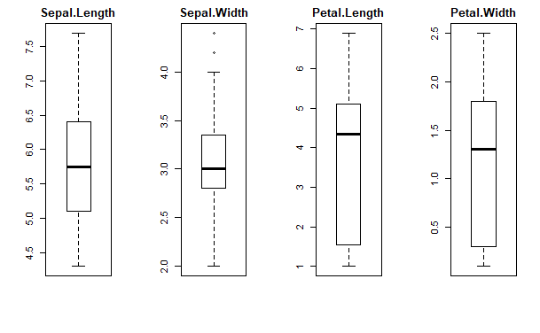

```r
# split input and output - the measurements define x, and the classes, y
x <- dataset[,1:4]
y <- dataset[,5]
# boxplot for each attribute on one image
par(mfrow=c(1,4))
  for(i in 1:4) {
  boxplot(x[,i], main=names(iris)[i])
}
```

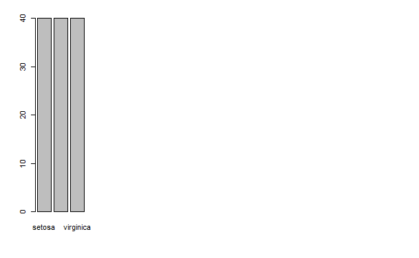

```r
# barplot for class breakdown
plot(y)
```

This tells me about the measurement distributions, and that the observations are equal in number.

///

Multivariate plots can tell me about the relationships between the different variables.

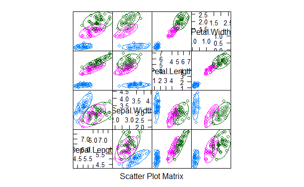

```r
# scatterplot matrix - this creates a chart of each variable plotted against every other, allowing trend recognition
featurePlot(x=x, y=y, plot="ellipse")
```

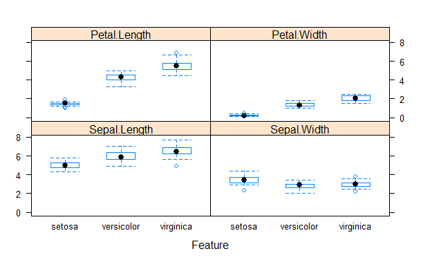

```r
# box and whisker plots for each attribute - as in the above boxplots, this allows distribution comparison, but also can identify clear differences between classes
featurePlot(x=x, y=y, plot="box")
```

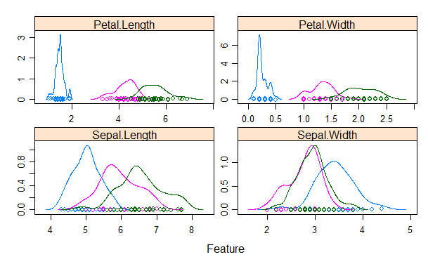

```r
# density plots for each attribute by class value - from this, I can see the distribution of each attribute in a mooth manner
scales <- list(x=list(relation="free"), y=list(relation="free"))
featurePlot(x=x, y=y, plot="density", scales=scales)
```

```r
#These look somewhat Gaussian!
```

Now that I have a deeper understanding of the data properties, it’s time to set up some ML algorithms for predicting the class of each flower from its attributes.

```r
# Run algorithms using 10-fold cross validation
control <- trainControl(method="cv", number=10)
metric <- "Accuracy"
```

I’ll use the 5 suggested algorithms for my dataset: LDA, CART, kNN, SVM, RF

```r
# a) linear algorithms
set.seed(7)
fit.lda <- train(Species~., data=dataset, method="lda", metric=metric, trControl=control)
# b) nonlinear algorithms
# CART
set.seed(7)
fit.cart <- train(Species~., data=dataset, method="rpart", metric=metric, trControl=control)
# kNN
set.seed(7)
fit.knn <- train(Species~., data=dataset, method="knn", metric=metric, trControl=control)
# c) advanced algorithms
# SVM
set.seed(7)
fit.svm <- train(Species~., data=dataset, method="svmRadial", metric=metric, trControl=control)
# Random Forest
set.seed(7)
fit.rf <- train(Species~., data=dataset, method="rf", metric=metric, trControl=control)
```

And then compare them in terms of accuracy

```r
#summarise accuracy of models
results <- resamples(list(lda=fit.lda, cart=fit.cart, knn=fit.knn, svm=fit.svm, rf=fit.rf))
summary(results)

# compare accuracy of models
dotplot(results)
```

[output not shown]

```r
# summarise Best Model
print(fit.lda)
```

[output not shown]

Using the LDA model, I want to get an idea of the accuracy of the model on the validation set, to quantify how well my choices have performed.

```r
# estimate skill of LDA on the validation dataset
predictions <- predict(fit.lda, validation)
confusionMatrix(predictions, validation$Species)
```

[output not shown]

///

To conclude, I have followed a tutorial guiding me through the principles of a machine learning project. I have explored and visualised a dataset, created 5 ML models, evaluated their accuracy, and verified that my chosen model is suitable. I now have the skills and the framework to perform further analyses on other data, using other models.